# Global Energy Analysis

How do countries achieve economic growth while maintaining low energy intensity?

Author

Angel Ho, Easha Rajalaxmi Vivesh

Published

December 8, 2024

# Introduction

The global pursuit of sustainable development faces a critical challenge: how can nations achieve economic growth while reducing their environmental footprint? From 2000 to 2019, economies worldwide have attempted to navigate this balance by transitioning to renewable energy, improving energy efficiency, and reducing carbon intensity. This report explores these trends and identifies key factors behind successful renewable energy transitions.

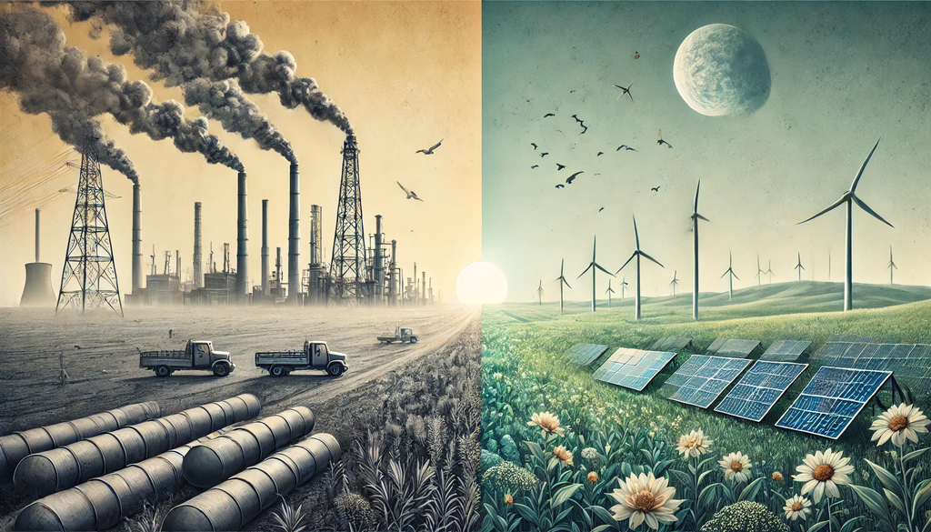

# Research Context & Significance

Our world faces the critical challenge of achieving economic growth without increasing environmental damage. While traditional development models suggest economic growth inevitably leads to higher energy use and emissions, recent studies challenge this assumption. The IPCC’s 2023 report emphasizes that some nations have successfully “decoupled” their economic growth from emissions growth.

Through analyzing global energy intensity patterns, we discover intriguing evidence: some countries have successfully grown their economies while keeping environmental impact low. What strategies enabled their success? What can other nations learn from these cases? This research examines how different countries achieve their development goals, particularly focusing on:

- Energy efficiency in economic growth
- Development patterns across different economies
- Strategies for sustainable growth

By understanding these patterns, we aim to identify successful pathways that could guide other nations toward sustainable development, especially as countries worldwide commit to ambitious climate goals under the Paris Agreement.

Reducing these environmental impacts while maintaining economic growth is a key challenge in sustainable development. Strategies such as improving energy efficiency, transitioning to cleaner energy sources, and implementing stricter environmental regulations are crucial in addressing this challenge.

## Research Question

**How do countries achieve economic growth while maintaining low energy intensity?**

**Which countries have successfully demonstrated that high growth and low environmental impact can coexist?**

# Data management

## Data source

### Global Data on Sustainable Energy (2000-2020)

The dataset available on [Kaggle](https://www.kaggle.com/datasets/anshtanwar/global-data-on-sustainable-energy/data) contains statistics related to sustainable energy usage and its implications across more than 150 countries over two decades. It covers a range of variables such as the share of renewable energy in total energy consumption, carbon dioxide emissions per capita, electricity access, and the availability of clean fuels for cooking. This data is crucial for analyzing global trends in renewable energy adoption and its effects on environmental and economic factors.

## Data Discussion

### Source of Data: [Global Data on Sustainable Energy (2000-2020)](https://www.kaggle.com/datasets/anshtanwar/global-data-on-sustainable-energy/data)

Ansh Tanwar compiled the dataset using data from the World Bank and International Energy Agency, with the majority sourced from ourworldindata.org. Additional features were integrated from top-rated Kaggle datasets to enrich the dataset.

### Data Collection by Original Sources

- 1. **World Bank and International Energy Agency:** Both institutions use globally standardized methodologies for data collection, focusing on a range of economic and energy-related statistics. This ensures accuracy and reliability in the data provided.
- 2. **[Our World in Data](https://ourworldindata.org/sdgs/affordable-clean-energy):** This platform synthesizes data from the above sources and others to offer a comprehensive view of global energy issues. Their segment on Affordable and Clean Energy provides detailed insights into energy access and sustainability, enhancing the data with rich visualizations and in-depth analysis. This approach makes complex data more accessible and actionable for research and policy-making.

## Data Preview

```r
glimpse(Energy)
```

```
#> Rows: 3,649
#> Columns: 21
#> $ Entity                                                           <chr> "Afgh…
#> $ Year                                                             <int> 2000,…
#> $ Access.to.electricity....of.population.                          <dbl> 1.613…
#> $ Access.to.clean.fuels.for.cooking                                <dbl> 6.20,…
#> $ Renewable.electricity.generating.capacity.per.capita             <dbl> 9.22,…
#> $ Financial.flows.to.developing.countries..US...                   <dbl> 20000…
#> $ Renewable.energy.share.in.the.total.final.energy.consumption.... <dbl> 44.99…
#> $ Electricity.from.fossil.fuels..TWh.                              <dbl> 0.16,…
#> $ Electricity.from.nuclear..TWh.                                   <dbl> 0, 0,…
#> $ Electricity.from.renewables..TWh.                                <dbl> 0.31,…
#> $ Low.carbon.electricity....electricity.                           <dbl> 65.95…
#> $ Primary.energy.consumption.per.capita..kWh.person.               <dbl> 302.5…
#> $ Energy.intensity.level.of.primary.energy..MJ..2017.PPP.GDP.      <dbl> 1.64,…
#> $ Value_co2_emissions_kt_by_country                                <dbl> 760, …
#> $ Renewables....equivalent.primary.energy.                         <dbl> NA, N…
#> $ gdp_growth                                                       <dbl> NA, N…
#> $ gdp_per_capita                                                   <dbl> NA, N…
#> $ Density.n.P.Km2.                                                 <chr> "60",…
#> $ Land.Area.Km2.                                                   <int> 65223…
#> $ Latitude                                                         <dbl> 33.93…
#> $ Longitude                                                        <dbl> 67.70…
```

## Data Cleaning

1. cleaning the column names

```r
Energy_data <- clean_names(Energy)

write_csv(Energy_data, here("data_processed", "energy_data.csv"))
```

2. Compact overview of the clean dataset

```r
glimpse(Energy_data)
```

```
#> Rows: 3,649
#> Columns: 21
#> $ entity                                                       <chr> "Afghanis…
#> $ year                                                         <int> 2000, 200…
#> $ access_to_electricity_of_population                          <dbl> 1.613591,…
#> $ access_to_clean_fuels_for_cooking                            <dbl> 6.20, 7.2…
#> $ renewable_electricity_generating_capacity_per_capita         <dbl> 9.22, 8.8…
#> $ financial_flows_to_developing_countries_us                   <dbl> 20000, 13…
#> $ renewable_energy_share_in_the_total_final_energy_consumption <dbl> 44.99, 45…
#> $ electricity_from_fossil_fuels_t_wh                           <dbl> 0.16, 0.0…
#> $ electricity_from_nuclear_t_wh                                <dbl> 0, 0, 0, …
#> $ electricity_from_renewables_t_wh                             <dbl> 0.31, 0.5…
#> $ low_carbon_electricity_electricity                           <dbl> 65.95744,…
#> $ primary_energy_consumption_per_capita_k_wh_person            <dbl> 302.5948,…
#> $ energy_intensity_level_of_primary_energy_mj_2017_ppp_gdp     <dbl> 1.64, 1.7…
#> $ value_co2_emissions_kt_by_country                            <dbl> 760, 730,…
#> $ renewables_equivalent_primary_energy                         <dbl> NA, NA, N…
#> $ gdp_growth                                                   <dbl> NA, NA, N…
#> $ gdp_per_capita                                               <dbl> NA, NA, 1…
#> $ density_n_p_km2                                              <chr> "60", "60…
#> $ land_area_km2                                                <int> 652230, 6…
#> $ latitude                                                     <dbl> 33.93911,…
#> $ longitude                                                    <dbl> 67.70995,…
```

# Core Analysis

## Energy Intensity Analysis:

The global pursuit of sustainable development faces a critical challenge: how can nations achieve economic growth while reducing their environmental footprint? From 2000 to 2019, economies worldwide have attempted to navigate this balance by transitioning to renewable energy, improving energy efficiency, and reducing carbon intensity. This report explores these trends and identifies key factors behind successful renewable energy transitions.

```r
# 1. Data Processing
# Filter data before 2020 and process core metrics
energy_intensity <- Energy_data %>%
 filter(year < 2020) %>%
 mutate(
   energy_intensity = as.numeric(as.character(energy_intensity_level_of_primary_energy_mj_2017_ppp_gdp)),
   co2_emissions = as.numeric(as.character(value_co2_emissions_kt_by_country)),
   gdp_growth = as.numeric(as.character(gdp_growth))
 ) %>%
 drop_na(energy_intensity, co2_emissions, gdp_growth)



# Classify countries based on energy efficiency and growth performance
country_averages <- energy_intensity %>%
 group_by(entity) %>%
 summarize(
   avg_energy_intensity = mean(energy_intensity, na.rm = TRUE),
   avg_co2_emissions = mean(co2_emissions, na.rm = TRUE),
   avg_gdp_growth = mean(gdp_growth, na.rm = TRUE),
   reliability = n()
 ) %>%
 filter(reliability >= 5) %>%
 mutate(
   performance = case_when(
     avg_gdp_growth > median(avg_gdp_growth) &
       avg_energy_intensity < median(avg_energy_intensity) ~ "High Performer",
     avg_gdp_growth > median(avg_gdp_growth) &
       avg_energy_intensity >= median(avg_energy_intensity) ~ "Growth at Environmental Cost",
     avg_gdp_growth <= median(avg_gdp_growth) &
       avg_energy_intensity < median(avg_energy_intensity) ~ "Eco-Efficient but Slow Growth",
     TRUE ~ "Struggling"
   )
 )

high_performers <- country_averages %>%
  filter(performance == "High Performer") %>%
  pull(entity)
```

### 1. Energy Intensity Trends Across the World

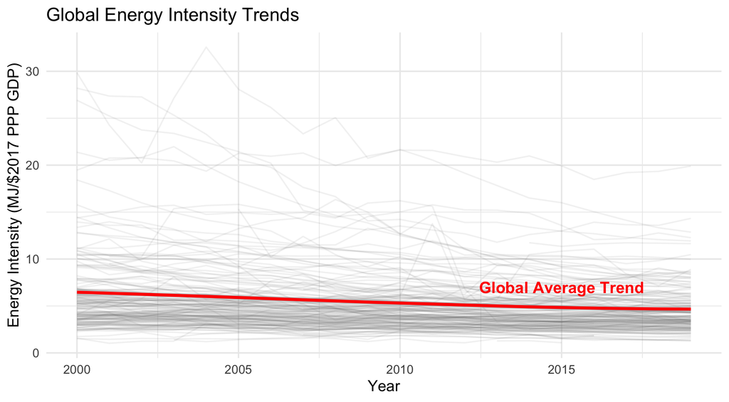

```r
trend_plot <- energy_intensity %>%
  group_by(year, entity) %>%
  summarize(
    avg_energy_intensity = mean(energy_intensity, na.rm = TRUE),
    .groups = "drop"
  ) %>%
  ggplot(aes(x = year, y = avg_energy_intensity, group = entity)) +
  geom_line(alpha = 0.1, color = "gray50") +
  geom_smooth(aes(group = 1), color = "red", method = "loess", se = TRUE) +
  labs(title = "Global Energy Intensity Trends",
       x = "Year",
       y = "Energy Intensity (MJ/$2017 PPP GDP)") +
  theme_minimal() +
  annotate("text", x = 2015, y = 7,
           label = "Global Average Trend",
           color = "red",
           size = 4,
           fontface = "bold")

trend_plot
```

Energy intensity is a key metric in understanding the relationship between energy consumption and economic output. It is calculated as the amount of energy used (measured in megajoules, MJ) per unit of gross domestic product. Lower energy intensity generally indicates a more energy-efficient economy, as it’s producing more economic value with less energy input.

The chart shows a steady global decline in energy intensity (MJ/$2017 PPP GDP) from 2000 to 2019, indicating overall improvements in energy efficiency. While the red line highlights this consistent global trend, the gray lines reveal variability among countries, with some making significant progress and others lagging.

This suggests that many nations are adopting more efficient practices, but disparities remain, offering opportunities for improvement.

### 2. Identifying Patterns of Successful Transitions

```r
performance_summary <- country_averages %>%
  group_by(performance) %>%
  summarize(
    country_count = n(),
    avg_growth = sprintf("%.1f%%", mean(avg_gdp_growth)),
    avg_intensity = sprintf("%.2f", mean(avg_energy_intensity)),
    avg_emissions = sprintf("%.1f kt", mean(avg_co2_emissions)),
    representative_countries = paste(
      head(entity[order(-avg_gdp_growth)], 3),
      collapse = ", "
    ),
    .groups = "drop"
  ) %>%
  arrange(as.numeric(avg_intensity))


performance_summary <- performance_summary %>%
  rename(
    "Performance Category" = performance,
    "Number of Countries" = country_count,
    "GDP Growth (%)" = avg_growth,
    "Energy Intensity (MJ/$)" = avg_intensity,
    "CO2 Emissions (kt)" = avg_emissions,
    "Representative Countries" = representative_countries
  )

performance_order <- c(
  "High Performer",
  "Eco-Efficient but Slow Growth",
  "Growth at Environmental Cost",
  "Struggling"
)
# Top performing countries in each category
top_countries <- country_averages %>%
  group_by(performance) %>%
  slice_max(order_by = avg_gdp_growth, n = 10) %>%
  select(performance, entity, avg_gdp_growth, avg_energy_intensity, avg_co2_emissions) %>%
  mutate(performance = factor(performance, levels = performance_order)) %>%
  arrange(performance, -avg_gdp_growth)


 performance_summary %>%
  kable(
    caption = "Global Performance Categories (2000-2020)",
    align = c('l', 'c', 'c', 'c', 'c', 'l'),
    format.args = list(big.mark = ",")
  ) %>%
  kable_styling(bootstrap_options = c("striped", "hover"))
```

Global Performance Categories (2000-2020)

| Performance Category | Number of Countries | GDP Growth (%) | Energy Intensity (MJ/$) | CO2 Emissions (kt) | Representative Countries |
| --- | --- | --- | --- | --- | --- |
| High Performer | 35 | 5.0% | 3.12 | 34843.3 kt | Equatorial Guinea, Djibouti, Afghanistan |
| Eco-Efficient but Slow Growth | 45 | 2.1% | 3.39 | 117931.3 kt | Guatemala, Ecuador, Paraguay |
| Struggling | 35 | 2.4% | 7.50 | 223006.3 kt | Bulgaria, Saudi Arabia, Belize |
| Growth at Environmental Cost | 45 | 5.9% | 7.69 | 251553.8 kt | Myanmar, Qatar, China |

**Key Results**

1. High Performers: Countries such as Equatorial Guinea, Djibouti, and Afghanistan balance strong GDP growth with low energy intensity, showcasing sustainable growth strategies.
2. Eco-Efficient but Slow Growth: Countries like Guatemala, Ecuador, and Paraguay have low energy intensity but relatively slow GDP growth, indicating they are energy efficient but may need economic stimulation.
3. Struggling: Countries like Bulgaria, Saudi Arabia, and Belize face challenges with both high energy intensity and low GDP growth, highlighting areas requiring significant policy intervention.
4. Growth at Environmental Cost: Countries like Myanmar, Qatar, and China show high GDP growth but at the expense of high energy intensity and emissions, indicating a need for energy efficiency improvements.

```r
# Calculate single reference lines based on all countries
overall_means <- top_countries %>%
  summarize(
    mean_growth = median(avg_gdp_growth),     # Using median instead of mean for better separation
    mean_intensity = median(avg_energy_intensity)
  )

performance_plot <- ggplot(top_countries,
   aes(x = avg_energy_intensity,
       y = avg_gdp_growth,
       color = performance,
       text = paste("Country:", entity,
                   "<br>GDP Growth:", round(avg_gdp_growth, 2), "%",
                   "<br>Energy Intensity:", round(avg_energy_intensity, 2)))) +
 # Add reference lines
 geom_hline(yintercept = mean(top_countries$avg_gdp_growth),
            linetype = "dashed", color = "gray50", alpha = 0.5) +
 geom_vline(xintercept = mean(top_countries$avg_energy_intensity),
            linetype = "dashed", color = "gray50", alpha = 0.5) +
 # Add reference line labels in better positions
 annotate("text",
          x = max(top_countries$avg_energy_intensity),
          y = mean(top_countries$avg_gdp_growth) + 0.3,
          label = "Average GDP Growth",
          color = "gray30",
          hjust = 1,
          size = 3.5) +
 annotate("text",
          x = mean(top_countries$avg_energy_intensity) + 0.5,
          y = max(top_countries$avg_gdp_growth) - 0.5,  # 移到更上面
          label = "Average Energy Intensity",
          color = "gray30",
          angle = 90,
          vjust = 1,
          size = 3.5) +
 # Add larger points
 geom_point(size = 4, alpha = 0.8) +
 # Visual customization with better colors
 scale_color_manual(values = c(
  "High Performer" = "#4CAF50",
  "Eco-Efficient but Slow Growth" = "#03A9F4",
  "Growth at Environmental Cost" = "#F44336",
  "Struggling" = "#8E5C42"
)) +
 scale_x_continuous(limits = c(0, max(top_countries$avg_energy_intensity) + 2)) +
 scale_y_continuous(limits = c(0, max(top_countries$avg_gdp_growth) + 1)) +
 labs(
   title = "GDP Growth vs. Energy Intensity",
   x = "Energy Intensity (MJ/$2017 PPP GDP)",
   y = "GDP Growth (%)",
   color = "Performance Category"
 ) +
 theme_minimal() +
 theme(
   legend.position = "right",
   plot.title = element_text(size = 14, face = "bold", margin = margin(b = 10)),
   plot.subtitle = element_text(size = 12, margin = margin(b = 20)),
   axis.title = element_text(size = 10),
   legend.title = element_text(size = 10),
   legend.text = element_text(size = 9),
   panel.grid.minor = element_blank(),
   panel.grid.major = element_line(color = "gray90")
 )

# Convert to interactive plot
interactive_plot <- ggplotly(performance_plot, tooltip = "text")
interactive_plot
```

[interactive chart not shown]

This chart reveals how countries navigate the balance between economic growth and energy efficiency, categorized into four distinct groups:

1. High Performers: Countries like Djibouti and Equatorial Guinea show that sustainable growth is possible, achieving high GDP growth with low energy intensity. Their success highlights the benefits of clean energy adoption and energy-efficient policies.
2. Energy-Efficient but Slow Growth: Nations such as Guatemala and Ecuador excel in energy efficiency but experience slower economic progress. They illustrate the need for strategies to stimulate growth without compromising sustainability.
3. Rapid Growth at Environmental Cost: Countries like China and Myanmar achieve high economic growth but rely heavily on energy-intensive industries. Their path emphasizes the urgent need for energy efficiency reforms and clean energy investments.
4. Struggling Economies: Nations like Saudi Arabia and Bulgaria face dual challenges of low economic growth and high energy intensity. These countries require international support and structural reforms to overcome inefficiencies.

### 3. Global Data Overview

```r
world_map <- ne_countries(scale = "medium", returnclass = "sf")

country_name_mapping <- c(
    "United States" = "United States of America",
    "Bosnia and Herzegovina" = "Bosnia and Herz.",
    "Central African Republic" = "Central African Rep.",
    "Dominican Republic" = "Dominican Rep.",
    "Equatorial Guinea" = "Eq. Guinea",
    "Eswatini" = "eSwatini",
    "North Macedonia" = "North Macedonia",
    "Sao Tome and Principe" = "São Tomé and Principe",
    "Solomon Islands" = "Solomon Is.",
    "Antigua and Barbuda" = "Antigua and Barb.",
    "Cayman Islands" = "Cayman Is.",
    "Myanmar" = "Myanmar",
    "United Kingdom" = "United Kingdom",
    "United Arab Emirates" = "United Arab Emirates"
)

# 3. Update data preparation
performance_map_data <- country_averages %>%
  mutate(
    region = case_when(
      entity %in% names(country_name_mapping) ~ country_name_mapping[entity],
      TRUE ~ entity
    )
  ) %>%
  select(region, performance, avg_gdp_growth, avg_energy_intensity, avg_co2_emissions)


# 4. Update map data join
world_map_data <- world_map %>%
  left_join(performance_map_data, by = c("name" = "region"))

# 5. Create updated map
world_performance_map <- ggplot() +
  geom_sf(data = world_map_data,
          aes(fill = performance,
              text = paste0("Country: ", name, "\n",
                          "Performance: ", performance, "\n",
                          "GDP Growth: ", round(avg_gdp_growth, 1), "%\n",
                          "Energy Intensity: ", round(avg_energy_intensity, 2))),
          color = "white",
          size = 0.1) +
  scale_fill_manual(values = c(
    "High Performer" = "#4CAF50",
    "Eco-Efficient but Slow Growth" = "#03A9F4",
    "Growth at Environmental Cost" = "#F44336",
    "Struggling" = "#8E5C42"
  ),
  name = "Performance Category",
  na.value = "grey90") +
  labs(title = "Global Energy Efficiency Performance (2000-2020)") +
  theme_minimal() +
  theme(
    axis.text = element_blank(),
    axis.title = element_blank(),
    panel.grid = element_blank(),
    plot.title = element_text(face = "bold", size = 14),
    legend.position = "right"
  )

# Convert to interactive map
interactive_map <- ggplotly(world_performance_map, tooltip = "text")
interactive_map
```

[interactive chart not shown]

Between 2000 and 2020, global renewable energy adoption has increased steadily, driven by technological advancements and policy initiatives. However, this progress is uneven across countries. Latin America has notable “Eco-Efficient but Slow Growth” performers, while much of Asia, including China and India, reflects “Growth at Environmental Cost.” Africa is divided between “Struggling” economies and high performers like Morocco. Grey areas indicate regions with insufficient or inconsistent data, limiting their analysis.

### 4. Deep Dive: Case Study Analysis

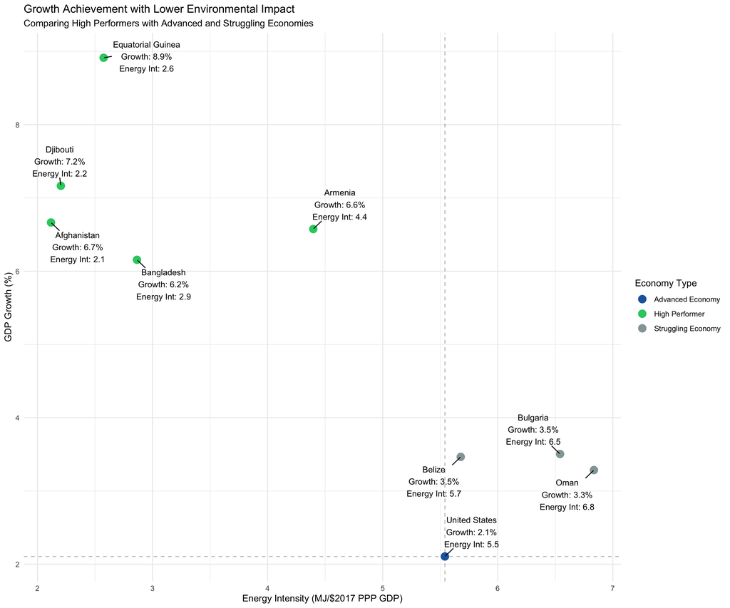

```r
key_success_factors <- country_averages %>%
  filter(entity %in% c(
    # Advanced Economy benchmark
    "United States",

    # High Performers
    "Equatorial Guinea",
    "Bangladesh",
    "Armenia",
    "Djibouti",
    "Afghanistan",

    # Struggling Economies
    "Bulgaria",
    "Belize",
    "Oman"
  )) %>%
  mutate(
    gdp_category = case_when(
      entity == "United States" ~ "Advanced Economy",
      entity %in% c("Bulgaria", "Saudi Arabia", "Belize", "Oman") ~ "Struggling Economy",
      TRUE ~ "High Performer"
    )
  )


ggplot(key_success_factors,
       aes(x = avg_energy_intensity, y = avg_gdp_growth)) +
  geom_hline(yintercept = key_success_factors$avg_gdp_growth[key_success_factors$entity == "United States"],
             linetype = "dashed", alpha = 0.3) +
  geom_vline(xintercept = key_success_factors$avg_energy_intensity[key_success_factors$entity == "United States"],
             linetype = "dashed", alpha = 0.3) +
  geom_point(aes(color = gdp_category), size = 4) +
  geom_text_repel(aes(label = sprintf("%s\nGrowth: %.1f%%\nEnergy Int: %.1f",
                                     entity,
                                     avg_gdp_growth,
                                     avg_energy_intensity)),
                  size = 3.5,
                  box.padding = 0.7) +
  scale_color_manual(values = c(
    "Advanced Economy" = "#2166AC",
    "High Performer" = "#2ecc71",
    "Struggling Economy" = "#95a5a6"
  )) +
  labs(title = "Growth Achievement with Lower Environmental Impact",
       subtitle = "Comparing High Performers with Advanced and Struggling Economies",
       x = "Energy Intensity (MJ/$2017 PPP GDP)",
       y = "GDP Growth (%)",
       color = "Economy Type") +
  theme_minimal()
```

Key Findings from the Visualization:

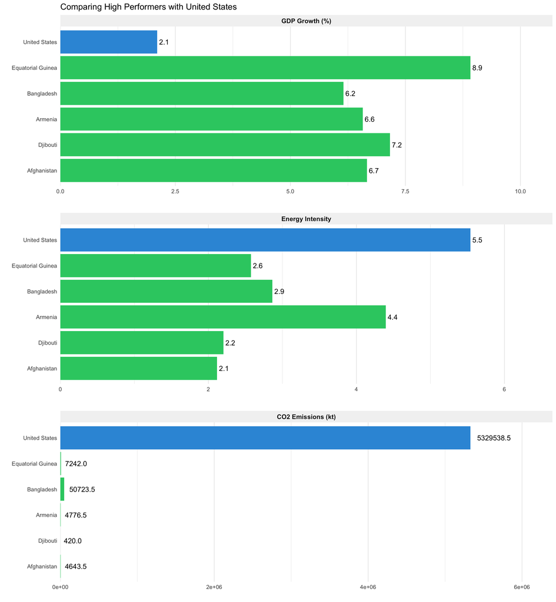

```r
# Key metrics comparison
benchmark_data <- country_averages %>%
  filter(entity %in% c(
    "Equatorial Guinea",
    "Bangladesh",
    "Armenia",
    "Djibouti",
    "Afghanistan",
    "United States")) %>%
  select(entity, avg_gdp_growth, avg_energy_intensity, avg_co2_emissions) %>%
  pivot_longer(cols = -entity, names_to = "metric", values_to = "value") %>%
  mutate(
    metric = case_when(
      metric == "avg_gdp_growth" ~ "GDP Growth (%)",
      metric == "avg_energy_intensity" ~ "Energy Intensity",
      metric == "avg_co2_emissions" ~ "CO2 Emissions (kt)"
    ),
    # Set the order of metrics
    metric = factor(metric, levels = c("GDP Growth (%)",
                                     "Energy Intensity",
                                     "CO2 Emissions (kt)"))
  ) %>%
  # Set USA as a special category
  mutate(country_type = ifelse(entity == "United States", "USA", "High Performer")) %>%
  # Sort countries within each metric (from highest to lowest)
  group_by(metric) %>%
  mutate(order = rank(-value)) %>%  # Use negative sign to sort in descending order
  ungroup()

# Create clean bar plot for key metrics
ggplot(benchmark_data,
       aes(y = reorder(entity, -order), x = value, fill = country_type)) +  # Note the use of -order for descending order
  geom_col() +
  facet_wrap(~ metric, scales = "free", ncol = 1) +
  geom_text(aes(label = sprintf("%.1f", value)),
            hjust = -0.2) +
  scale_fill_manual(values = c(
    "High Performer" = "#2ecc71",  # Unified green for High Performers
    "USA" = "#3498db"              # Blue for the USA
  )) +
  theme_minimal() +
  theme(
    axis.text.y = element_text(hjust = 1),
    legend.position = "none",
    strip.text = element_text(face = "bold", size = 10),
    panel.grid.major.y = element_blank(),
    strip.background = element_rect(fill = "grey95", color = NA),
    panel.spacing = unit(2, "lines")
  ) +
  labs(
    title = "Comparing High Performers with United States",
    x = "",
    y = ""
  ) +
  scale_x_continuous(expand = expansion(mult = c(0, 0.2)))
```

Key Insights from Metrics Comparison

1. GDP Growth: The U.S. grows at 2.1%, far behind high performers like Equatorial Guinea (8.9%) and Djibouti (7.2%), showing opportunities for economic rejuvenation.
2. Energy Intensity: The U.S. has the highest energy intensity (5.5 MJ/$), while Afghanistan (2.1) and Djibouti (2.2) lead in efficiency, reflecting their leaner energy usage.
3. CO2 Emissions: U.S. emissions (5.3M kt) dwarf others like Equatorial Guinea (7,242 kt) and Djibouti (420 kt), highlighting the urgent need for decarbonization.
4. High performers achieve growth with efficiency and low emissions, while the U.S. must prioritize clean energy and efficiency to align with sustainable goals.

#### Regression Analysis

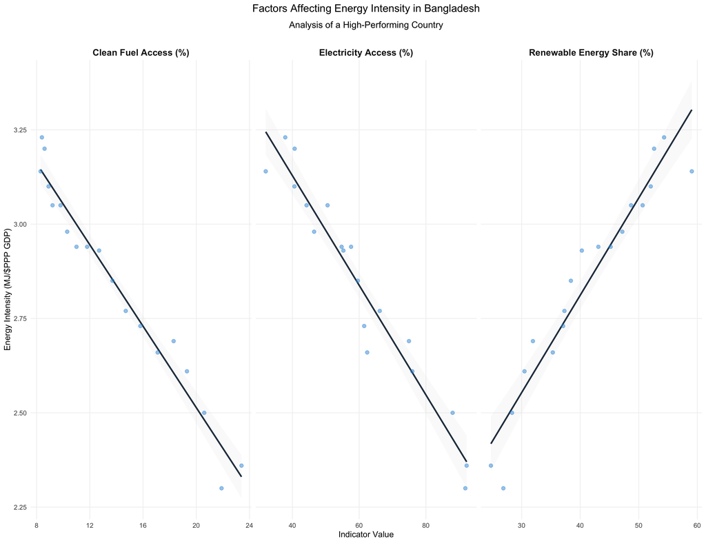

```r
# Filter data to include target and predictor variables
regression_data <- Energy_data %>%
  filter(entity == "Bangladesh") %>%
  select(
    year,
    energy_intensity_level_of_primary_energy_mj_2017_ppp_gdp,
    renewable_energy_share_in_the_total_final_energy_consumption,
    value_co2_emissions_kt_by_country,
    electricity_from_fossil_fuels_t_wh,
    electricity_from_renewables_t_wh,
    financial_flows_to_developing_countries_us,
    access_to_clean_fuels_for_cooking,
    access_to_electricity_of_population
  ) %>%
  drop_na()

# Build a regression model
energy_intensity_model <- lm(
  energy_intensity_level_of_primary_energy_mj_2017_ppp_gdp ~
    renewable_energy_share_in_the_total_final_energy_consumption +
    value_co2_emissions_kt_by_country +
    electricity_from_fossil_fuels_t_wh +
    electricity_from_renewables_t_wh +
    financial_flows_to_developing_countries_us +
    access_to_clean_fuels_for_cooking +
    access_to_electricity_of_population,
  data = regression_data
)

# Select and prepare significant variables
significant_vars <- regression_data %>%
 select(
   energy_intensity_level_of_primary_energy_mj_2017_ppp_gdp,
   access_to_clean_fuels_for_cooking,
   access_to_electricity_of_population,
   renewable_energy_share_in_the_total_final_energy_consumption
 ) %>%
 pivot_longer(
   cols = -energy_intensity_level_of_primary_energy_mj_2017_ppp_gdp,
   names_to = "variable",
   values_to = "value"
 )

# Create improved scatter plots
scatter <- ggplot(significant_vars,
      aes(x = value,
          y = energy_intensity_level_of_primary_energy_mj_2017_ppp_gdp)) +
 # Add trend line with confidence interval
 geom_smooth(method = "lm",
             color = "#2c3e50",
             fill = "grey90",
             alpha = 0.2) +
 # Add data points
 geom_point(color = "#3498db",
            size = 2,
            alpha = 0.5) +
 facet_wrap(~ variable,
            scales = "free_x",
            labeller = as_labeller(c(
              "access_to_clean_fuels_for_cooking" = "Clean Fuel Access (%)",
              "access_to_electricity_of_population" = "Electricity Access (%)",
              "renewable_energy_share_in_the_total_final_energy_consumption" = "Renewable Energy Share (%)"
            ))) +
 labs(
   title = "Factors Affecting Energy Intensity in Bangladesh",
   subtitle = "Analysis of a High-Performing Country",
   x = "Indicator Value",
   y = "Energy Intensity (MJ/$PPP GDP)"
 ) +
 theme_minimal() +
 theme(
   strip.text = element_text(size = 12, face = "bold"),
   plot.title = element_text(hjust = 0.5, size = 14, margin = margin(b = 10)),
   plot.subtitle = element_text(hjust = 0.5, size = 12, margin = margin(b = 20)),
   panel.grid.minor = element_blank(),       # Remove minor grid lines
   panel.grid.major = element_line(color = "grey95")  # Lighten major grid lines
 )


scatter
```

## The Impact of Renewable Energy Adoption on Carbon Emissions: A Global Perspective

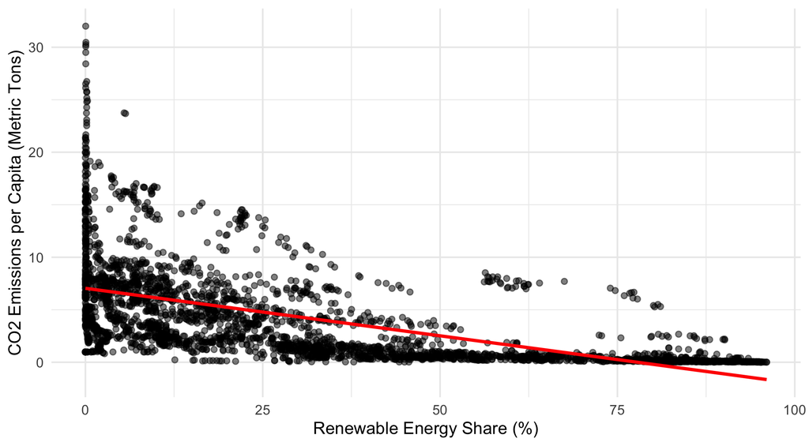

```r
# Calculating CO2 emissions per capita
EnergyShare <- Energy_data %>%
  # Converting character to numeric
  mutate(density_n_p_km2 = as.numeric(density_n_p_km2),
         # Calculating population
         population = density_n_p_km2 * land_area_km2,
         # Calculating CO2 emissions per capita (in metric tons)
         co2_per_capita = (value_co2_emissions_kt_by_country * 1000) / population)

# plotting with per capita emissions
ggplot(EnergyShare, aes(x = renewable_energy_share_in_the_total_final_energy_consumption,
                        y = co2_per_capita)) +
  geom_point(alpha = 0.5) +
  geom_smooth(method = "lm", se = FALSE, color = "red") +
  labs(x = "Renewable Energy Share (%)",
       y = "CO2 Emissions per Capita (Metric Tons)") +
  theme_minimal()
```

```r
cor(EnergyShare$renewable_energy_share_in_the_total_final_energy_consumption,
    EnergyShare$co2_per_capita, use = "complete.obs")
```

```
#> [1] -0.6027891
```

- The correlation coefficient of -0.6027891 indicates a moderate negative relationship between the share of renewable energy in total final energy consumption and CO2 emissions per capita.
- This means that as the share of renewable energy increases, CO2 emissions per capita tend to decrease.
- This correlation supports the idea that increasing the share of renewable energy might contribute to reducing carbon emissions on a per capita basis.

# Conclusion

This study reveals a complex but promising landscape in the global pursuit of sustainable development. Our analysis of energy intensity trends, economic growth patterns, and CO2 emissions across nations from 2000 to 2019 yields several key insights:

- Decoupling Growth and Emissions: Contrary to traditional development models, some countries have successfully “decoupled” economic growth from energy intensity and emissions growth. High performers like Bangladesh and Djibouti demonstrate that robust GDP growth is achievable while maintaining low energy intensity.Nations such as Guatemala and Ecuador excel in energy efficiency but experience slower economic progress. This illustrates the need for strategies to stimulate growth without compromising sustainability.
- Diverse Pathways: The global map of energy efficiency performance highlights stark contrasts between regions, emphasizing that there is no one-size-fits-all approach to sustainable development. High-income nations often lead in renewable deployment, while developing economies face unique challenges in balancing growth with environmental stewardship.
- Renewable Energy’s Role: A moderate negative correlation (-0.60) between renewable energy share and CO2 emissions per capita suggests that increasing renewable energy adoption contributes to reducing carbon footprints. This relationship underscores the importance of clean energy transitions in combating climate change.
- Policy Implications: The success of high-performing countries offers valuable lessons for others. Strategies such as modernizing energy infrastructure, promoting clean cooking fuels, and investing in less energy-intensive sectors can significantly impact a nation’s energy efficiency and emissions profile.

# Attribution

All members contributed equally

# Appendix

## Appendix A: Energy_data Dictionary

[output not shown]